# Distribuições de probabilidade comuns que cientistas de dados devem conhecer

Rogério Guerra da Silveira

28/08/2019

## Introdução [^1]

Comecemos com um exemplo: suponha que você é um professor de MBA em Ciência de Dados e decidiu analisar o modo como as notas dos alunos ao longo do ano se comportam. Após a secretaria lançar os graus em uma planilha, obtém-se a seguinte figura:

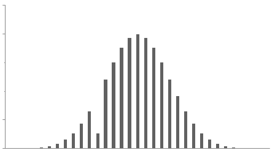

Figura 1 - Notas

O gráfico da Figura 1 é chamado **distribuição de frequências** dos dados. Pode-se inferir uma estrutura suave curvilínea que define os dados, mas é aparente que há uma anomalia. Nota-se que há uma frequência anormalmente baixa para uma determinada faixa de notas. É possível que estes dados tenham sido mal anotados ou registrados?

Um **cientista de dados**, seja um estudante ou um profissional, emprega a arte e a ciência da análise de dados para resolver problemas do mundo real. Para tal tarefa não é, necessariamente, um profundo conhecedor da teoria de probabilidade e da estatística, ou um exímio cientista de computação, mas deve unir esses campos do conhecimento. Desse modo, cria conhecimento a partir de dados por meio de métodos quantitativos e de programação e o conhecimento do domínio em estudo. É a combinação de conhecimentos e habilidades abrangentes (mas não especializados) nessas áreas que fazem um cientista de dados.

Este trabalho apresenta de modo bastante sintético os conceitos, as definições e alguns exemplos de emprego de um desses conhecimentos fundamentais: as distribuições de probabilidade mais comuns e seu uso com o R. Há um [bom tutorial](http://www.r-tutor.com/elementary-statistics/probability-distributions) para se conhecer mais sobre as distribuições elementares em R. No que se segue, assume-se apenas um conhecimento básico de probabilidade.

## Índice

1. Tipos comuns de dados numéricos
2. Tipos de distribuição de probabilidade
   - Bernoulli
   - Uniforme
   - Binomial
   - Normal
   - Poisson
   - Exponencial
3. Relações entre distribuições
4. Teste o seu conhecimento!

### 1. Tipos comuns de dados numéricos

**Dados numéricos** podem ser discretos ou contínuos.

**Dados discretos**, como o nome sugere, podem assumir apenas alguns valores específicos. Por exemplo, quando se joga um dado, os resultados possíveis são 1, 2, 3, 4, 5 ou 6, ou seja, números inteiros entre 1 e 6.

**Dados contínuos**, podem assumir qualquer valor dentro de um determinado intervalo de valores (domínio). Note que o domínio pode ser finito ou infinito. Por exemplo, a receita de venda de uma determinada empresa em um certo período ou o peso ou a altura de uma pessoa.

### 2. Tipos de distribuição de probabilidade

#### Bernoulli

Comecemos com a distribuição mais simples de todas a distribuição de Bernoulli. Ela serve de modelo para, por exemplo, o lançamento de uma moeda, que pode mostrar um de dois resultados: “cara” ou “coroa”.

A distribuição de Bernoulli possui apenas dois resultados possíveis: 1 (sucesso) ou 0 (insucesso), e apenas uma tentativa (chamada de experimento). Então, definindo a variável aleatória X como sendo o resultado numérico do experimento, ela possui a distribuição de Bernoulli e pode assumir o valor 1 com a probabilidade de sucesso, digamos, *p*, e 0 com a probabilidade de insucesso *q* = 1 – *p*.

Aqui, a ocorrência de uma “cara” pode denotar um sucesso, enquanto uma “coroa” está associada a um insucesso (ou fracasso). Se a moeda for não-viciada, espera-se que as probabilidades de ocorrência de cada uma das faces sejam idênticas, ou seja, *p* = *q* = 0,5.

A função (massa) de probabilidade é uma função que associa a cada possível ocorrência de uma variável aleatória discreta uma probabilidade. No caso da distribuição de Bernoulli, temos $p(x) = {p}^{x} {(1-p)}^{1-x}$, *x* $\in$ {0, 1}.

Pode-se definir essa função como

$p(x)=\left\{\begin{matrix} p, & x=1\\ 1-p, & x=0 \end{matrix}\right.$

As probabilidades de sucesso e falha não precisam ser iguais. Por exemplo, considere um processo de prospecção de petróleo em um determinado campo no mar, onde foi estimada, por meio de estudos geológicos, que a probabilidade (chamada de probabilidade anterior, ou *prior*, isto é, antes de se realizar a perfuração) de haver petróleo é de 25%. Neste caso *p* = 0,25 e *q* = 0,75.

Um outro exemplo bastante comum refere-se à previsão de ocorrência de chuva em uma determinada hora: se a previsão é de 60% para as próximas cinco horas, **pode chover ou não** em cada hora seguinte. A previsão é realizada a partir de modelos que analisam as condições meteorológicas do passado e buscam estimar a probabilidade de chuva no futuro próximo, buscando padrões.

Em R, para se gerar cinco variáveis com esta distribuição, usa-se:

```r
set.seed(1959)
rbinom(5,1,0.60)
```

```
## [1] 1 1 0 0 0
```

Na realidade, utilizamos a distribuição Binomial (veremos em breve!) para gerar as cinco variáveis Bernoulli. Nessa simulação, choverá apenas nas próximas duas horas!

##### Parâmetros da distribuição de Bernoulli

O valor esperado (ou expectância) de qualquer distribuição de probabilidade (mais precisamente, de uma variável aleatória com esta distribuição) é a média da função. O valor esperado de uma variável aleatória x com uma distribuição de Bernoulli é:

$E(X)=1\times p + 0\times (1-p)=p$

[^1]: Parte do conteúdo deste trabalho está baseado em texto publicado por ANALYTICS VIDHYA CONTENT TEAM, em 18 de setembro de 2017